# Estimating Political Affiliation on Reddit

Alex Richardson  
12/4/2019

### Problem

Can we predict a Reddit user's political affiliation using his or her comment data and metadata?

- Reddit comments come with no demographic information
- Relatively few explicitely mention candidates
- A measure of political affiliation would be useful in studying other things (like propaganda)

### Where Do We Get Reddit Comments?

Pushshift.io maintains an API (but the wrapper is in Python)

Start by picking out dates and picking your users:

```python
start_epoch=int(dt.datetime(2016, 1, 1).timestamp()) # Start Date
end_epoch=int(dt.datetime(2016, 12, 31).timestamp()) # End Date

py_comm_auth_list = r.comment_author_list # Pull the author list over from R
```

### Call Some Generator Objects

```python
comment_history_gen = [] # Initialize somewhere to put generator objects
for n in py_comm_auth_list: # Iterate through the usernames
  print(n) # Reassure yourself that something is actually happening
  temp3list = api.search_comments(after=start_epoch,
                            before=end_epoch,
                            author=n,
                            )
  comment_history_gen.append(temp3list) # Append your generator objects
```

### Turn Generator Objects into Comments

The API returns generator objects which turn into a specific Reddit API object:

```python
hist_caches_list = [] # Somewhere to put them
hist_cache = [] # Somewhere to hold them in the short term
for c in comment_history_gen: # Iterate again
    for d in c:
      hist_cache.append(d)
    hist_caches_list.append(hist_cache)
```

### Turn Comments into a DataFrame

Finally, that object has to be turned into a dataframe using Pandas

```python
dataset = pd.DataFrame() # Initialize a dataframe
x = 0 # Create an index
for n in hist_caches_list: # Iterate again
    for o in n: # Iterate through *that*
        dataset = dataset.append(pd.DataFrame(o.d_, index=[x])) # Turn the object into a dictionary and then into a dataframe with index x
        x+=1 # Incriment x
```

### Dataset!

```
Observations: 76,352
Variables: 23
$ X1                     <dbl> 0, 1, 2, 3, 4, 5, 6, 7, 8, 9, 10, 11, 1...
$ author                 <chr> "Crysack", "Crysack", "Crysack", "Crysa...
$ author_created_utc     <dbl> 1398133613, 1398133613, 1398133613, 139...
$ author_flair_css_class <chr> "sfvvega", "sfvvega", "sfvvega", "sfvve...
$ author_flair_text      <chr> NA, NA, NA, NA, NA, NA, NA, NA, NA, NA,...
$ author_fullname        <chr> "t2_g8rci", "t2_g8rci", "t2_g8rci", "t2...
$ body                   <chr> "Vega is just as good as he was in S1, ...
$ controversiality       <dbl> 0, 0, 0, 0, 0, 0, 0, 0, 0, 0, 0, 0, 0, ...
$ created                <dbl> 1482996361, 1482822712, 1482641396, 148...
$ created_utc            <dbl> 1482978361, 1482804712, 1482623396, 148...
$ distinguished          <lgl> NA, NA, NA, NA, NA, NA, NA, NA, NA, NA,...
$ edited                 <dbl> NA, NA, NA, NA, NA, NA, NA, NA, NA, NA,...
$ gilded                 <dbl> 0, 0, 0, 0, 0, 0, 0, 0, 0, 0, 0, 0, 0, ...
$ id                     <chr> "dbqo446", "dbnwluf", "dbliek6", "dblhi...
$ link_id                <chr> "t3_5kr8va", "t3_5kf4zo", "t3_5k4nsw", ...
$ nest_level             <dbl> 2, 1, 2, 2, 2, 2, 1, 3, 10, 8, 6, 2, 1,...
$ parent_id              <chr> "t1_dbq2vmo", "t3_5kf4zo", "t1_dblfzxq"...
$ reply_delay            <dbl> 28723, 26229, 3890, 10597, 6481, 24943,...
$ retrieved_on           <dbl> 1484115662, 1484065268, 1484022626, 148...
$ score                  <dbl> 1, 1, 1, -1, 1, 1, 3, 1, 1, 1, 4, 2, 1,...
$ stickied               <lgl> FALSE, FALSE, FALSE, FALSE, FALSE, FALS...
$ subreddit              <chr> "StreetFighter", "StreetFighter", "Stre...
$ subreddit_id           <chr> "t5_2qnu5", "t5_2qnu5", "t5_2qnu5", "t5...
```

### Topic Model

Topic Models for Political Subreddits

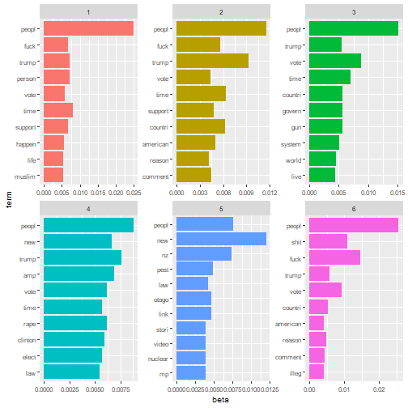

### Cleaning the Data

I limited the data to candidate mentions:

```r
can_comments = user_comments %>% filter((str_detect(body, "trump")) | (str_detect(body, "donald")) | (str_detect(body, "hillary")) | (str_detect(body, "clinton")) | (str_detect(body, "sanders")) | (str_detect(body, "bernie")) | (str_detect(body, "Trump")) | (str_detect(body, "Donald")) | (str_detect(body, "Hillary")) | (str_detect(body, "Clinton")) | (str_detect(body, "Sanders")) | (str_detect(body, "Bernie")))
```

### Cleaning the Data

And applied the afinn sentiment dictionary, grouping by author and the candidate mentioned:

```r
sent_dict <- get_sentiments("afinn")
sent_text <- user_words_can %>% inner_join(sent_dict)
sent_text <- sent_text %>% group_by(author, mention)
sum_sent_text <- sent_text %>% summarize(Average_Sentiment = mean(value))
sum_sent_text
```

### Applying a Sentiment Score

To get an overall affiliation score, I added the sentiment scores for Bernie's and Hillary's, minus Trump's. (I'll be exploring this with more nuance later.)

```r
sum_sent_text = sum_sent_text %>% spread(mention, Average_Sentiment)
sum_sent_text[is.na(sum_sent_text)] <- 0
sum_sent_text = sum_sent_text %>% mutate(Democrat = Bernie+Hillary-Donald)

sum_sent_text = sum_sent_text %>% select(author, Democrat)
```

### Applying a Sentiment Score

I then added these scores back onto each user in the main dataset.

```r
can_comments_sent = can_comments %>% full_join(sum_sent_text)
```

### Making Folds for Cross-Validation

After creating a few other variables, we're ready to prep for some models:

```r
set.seed(1989)

folds <- createFolds(train_data2$Democrat, k = 5)

sapply(folds,length)
```

```
Fold1 Fold2 Fold3 Fold4 Fold5
   10    10     9     8     8
```

As you can see, the dataset is extremely small by now. (I'm scaling up!)

### Random Forest

```r
mod_rf <-
  train(Democrat ~ ., # Equation (outcome and everything else)
        data=train_data2, # Training data
        method = "ranger", # random forest (ranger is much faster than rf)
        metric = "RMSE",     # mean squared error
        trControl = control_conditions,
  )
```

### Random Forest

```
Random Forest

45 samples
23 predictors

No pre-processing
Resampling: Cross-Validated (10 fold)
Summary of sample sizes: 10, 10, 9, 8, 8
Resampling results across tuning parameters:

  mtry  splitrule   RMSE       Rsquared    MAE
   2    variance    0.2401817  0.01829028  0.1893628
   2    extratrees  0.2396900  0.00880793  0.1882985
  34    variance    0.2376551  0.06161441  0.1927676
  34    extratrees  0.2397503  0.02764616  0.1920649
  66    variance    0.2369822  0.07490162  0.1927683
  66    extratrees  0.2376980  0.03343746  0.1916501

Tuning parameter 'min.node.size' was held constant at a value of 5
RMSE was used to select the optimal model using the smallest value.
The final values used for the model were mtry = 66, splitrule =
 variance and min.node.size = 5.
```

### KNN

```r
knn_tune = expand.grid(k = c(1,3,5,7))
mod_knn <-
  train(Democrat ~ .,           # Equation (outcome and everything else)
        data=train_data2,  # Training data
        method = "knn",    # K-Nearest Neighbors Algorithm
        metric = "RMSE",   # mean squared error
        trControl = control_conditions, # Cross validation conditions
        tuneGrid = knn_tune # Vary the tuning parameter K
  )
```

### KNN

```
k-Nearest Neighbors

45 samples
23 predictors

No pre-processing
Resampling: Cross-Validated (10 fold)
Summary of sample sizes: 10, 10, 9, 8, 8
Resampling results across tuning parameters:

  k  RMSE       Rsquared     MAE
  1  0.3465686  0.018886334  0.2792795
  3  0.2679932  0.012193704  0.2157626
  5  0.2511045  0.004651039  0.1996105
  7  0.2409382  0.003507965  0.1888083

RMSE was used to select the optimal model using the smallest value.
The final value used for the model was k = 7.
```

### Linear

```r
mod_lm <-
  train(Democrat ~ .,          # Equation (outcome and everything else)
        data=train_data2, # Training data
        method = "lm",    # linear model
        metric = "RMSE",   # mean squared error
        trControl = control_conditions # Cross validation conditions
  )
```

### Linear

```
Linear Regression

45 samples
23 predictors

No pre-processing
Resampling: Cross-Validated (10 fold)
Summary of sample sizes: 10, 10, 9, 8, 8
Resampling results:

  RMSE       Rsquared  MAE
  0.2767028  NaN       0.2258895

Tuning parameter 'intercept' was held constant at a value of TRUE
```

### Picking a Winner

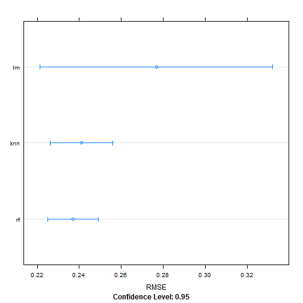

### Challenges

There are so many.

- High RMSE (Would ROC be better?)
- Extremely small relevant dataset
- Sentiment analysis is unreliable
- RStudio has completely lost Python(!)
- A larger dataset will include more subreddits as significant variables (processing power)

### Plans for Future

Turning this into a final project will require a few more important steps:

- Pulling in a much larger dataset
- Classifying political affinity as a categorical to use SVM
- Exploring differences between Hillary & Bernie
- Considering SASA to account for sarcasm, etc.
- Explore time-series elements